# Homework 02

## Question 1: Training and test error under a fixed design

Consider a linear regression problem with $n=100$ observations and $p=20$ available covariates. Generate one matrix $\mathbf X_{\mathrm{all}}\in\mathbb R^{n\times p}$ whose entries are independent $\mathcal N(0,1)$ random variables, and then keep this realized matrix fixed. Let

$$\beta_j=0.4^{\sqrt{j}},
\qquad j=1,\ldots,p,$$

and define

$$\boldsymbol\mu=\mathbf X_{\mathrm{all}}\boldsymbol\beta.$$

Generate one training response and one independent test response from

$$\begin{aligned}
\mathbf y
&=\boldsymbol\mu+\boldsymbol\epsilon,\\
\mathbf y^*
&=\boldsymbol\mu+\boldsymbol\epsilon^*,
\end{aligned}$$

where

$$\boldsymbol\epsilon,\boldsymbol\epsilon^*
\overset{\mathrm{ind}}{\sim}
\mathcal N_n(\mathbf 0,\mathbf I_n).$$

Here $\mathbf I_n$ is the $n\times n$ identity matrix.

For $m=0,1,\ldots,p$, fit a linear model with an intercept and the first $m$ columns of $\mathbf X_{\mathrm{all}}$ using $\mathbf y$. If $\widehat{\mathbf y}_m$ is its fitted mean vector, define

$$\operatorname{MSE}_{\mathrm{train},m}
=\frac{1}{n}
\left\lVert
\mathbf y-\widehat{\mathbf y}_m
\right\rVert_2^2,$$

and

$$\operatorname{MSE}_{\mathrm{test},m}
=\frac{1}{n}
\left\lVert
\mathbf y^*-\widehat{\mathbf y}_m
\right\rVert_2^2.$$

Repeat this process independently 200 times, keeping $\mathbf X_{\mathrm{all}}$ fixed.

Use seed `43202` before generating $\mathbf X_{\mathrm{all}}$ and the response errors. R and Python use different random-number generators, so their exact numerical values need not agree.

1. For each $m$, calculate the average training and test MSE over the 200 simulation runs. Plot both curves against $m$. Verify numerically that training MSE does not increase as predictors are added in each simulation run.
2. For the model containing the first $m$ predictors, write

$$\mathbf X_m
=
[\mathbf 1,\mathbf x_1,\ldots,\mathbf x_m],
\qquad
\mathbf H_m
=
\mathbf X_m
(\mathbf X_m^{\mathsf T}\mathbf X_m)^{-1}
\mathbf X_m^{\mathsf T}.$$

Here $\mathbf X_m\in\mathbb R^{n\times(m+1)}$ and $\mathbf H_m\in\mathbb R^{n\times n}$. The model has $m+1$ fitted coefficients, including the intercept. Define its **total squared approximation bias** as

$$B_m^2
=\left\lVert
(\mathbf I_n-\mathbf H_m)\boldsymbol\mu
\right\rVert_2^2.$$

Thus, $B_m^2/n$ is the mean squared approximation bias.

Calculate the two theoretical expectations

$$E\!\left(
\operatorname{MSE}_{\mathrm{train},m}
\mid \mathbf X_{\mathrm{all}}
\right)
=\frac{B_m^2}{n}+1-\frac{m+1}{n},$$

and

$$E\!\left(
\operatorname{MSE}_{\mathrm{test},m}
\mid \mathbf X_{\mathrm{all}}
\right)
=\frac{B_m^2}{n}+1+\frac{m+1}{n}.$$

Add these expectations to your plot and compare them with the simulation averages.

3. Add the test MSE curve from one simulation run to the plot. Explain why this single curve is less smooth than the average test MSE. Use the approximation-bias and estimation-variance terms in the expected test MSE to explain why training MSE cannot be used by itself to select the predictor count.

### Answer

**Show the starter code**

```r
set.seed(43202)

n <- 100
p <- 20
nsim <- 200

X_all <- matrix(rnorm(n * p), n, p)      # generated once, then held fixed
beta  <- 0.4^sqrt(1:p)
mu    <- as.vector(X_all %*% beta)

# 200 independent training/test response pairs sharing the same mu
Y     <- matrix(rnorm(n * nsim), n, nsim) + mu
Ystar <- matrix(rnorm(n * nsim), n, nsim) + mu
```

**(a) Average training and test MSE.**

**Show the starter code**

```r
train <- test <- matrix(NA_real_, p + 1, nsim)
B2    <- numeric(p + 1)

for (m in 0:p) {
  Xm <- if (m == 0) matrix(1, n, 1) else cbind(1, X_all[, 1:m, drop = FALSE])
  Q  <- qr.Q(qr(Xm))                     # orthonormal basis, so H = Q Q'
  Yhat <- Q %*% (t(Q) %*% Y)

  train[m + 1, ] <- colMeans((Y     - Yhat)^2)
  test [m + 1, ] <- colMeans((Ystar - Yhat)^2)

  B2[m + 1] <- sum((mu - Q %*% (t(Q) %*% mu))^2)   # ||(I - H_m) mu||^2
}

avg_train <- rowMeans(train)
avg_test  <- rowMeans(test)

# training MSE must not increase as predictors are added, within every run
step_changes <- apply(train, 2, diff)
c(max_increase_observed = max(step_changes),
  all_runs_non_increasing = all(step_changes <= 1e-10))
```

```
  max_increase_observed all_runs_non_increasing
          -4.128697e-11            1.000000e+00
```

**Show the starter code**

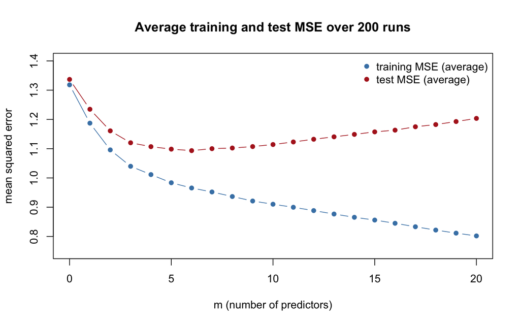

```r
plot(0:p, avg_test, type = "b", pch = 16, col = "firebrick", ylim = c(0.75, 1.40),
     xlab = "m (number of predictors)", ylab = "mean squared error",
     main = "Average training and test MSE over 200 runs")
lines(0:p, avg_train, type = "b", pch = 16, col = "steelblue")
legend("topright", bty = "n", pch = 16, col = c("steelblue", "firebrick"),
       legend = c("training MSE (average)", "test MSE (average)"))
```

The check returns a maximum step change of about $-4\times10^{-11}$, which is negative to within rounding, so training MSE never increased in any of the $200 \times 20$ steps. This is not a numerical accident. The models are nested: the column space of $\mathbf X_m$ is contained in that of $\mathbf X_{m+1}$, so any fit achievable with $m$ predictors is still achievable with $m+1$. Least squares minimizes the residual sum of squares over a larger set, so the minimum can only fall.

The two curves behave completely differently. Training MSE decreases steadily all the way to $m = 20$. Average test MSE falls sharply, bottoms out around $m = 6$, and then rises again. Adding predictors past that point makes the fit look better on the data used to fit it while making genuine predictions worse.

**(b) Theoretical expectations.**

**Show the starter code**

```r
th_train <- B2 / n + 1 - (0:p + 1) / n
th_test  <- B2 / n + 1 + (0:p + 1) / n

round(data.frame(
  m         = 0:p,
  bias2_n   = B2 / n,
  avg_train = avg_train, th_train = th_train,
  avg_test  = avg_test,  th_test  = th_test
), 4)
```

```
    m bias2_n avg_train th_train avg_test th_test
1   0  0.3074    1.3182   1.2974   1.3367  1.3174
2   1  0.1963    1.1873   1.1763   1.2347  1.2163
3   2  0.1172    1.0959   1.0872   1.1610  1.1472
4   3  0.0719    1.0398   1.0319   1.1202  1.1119
5   4  0.0522    1.0115   1.0022   1.1070  1.1022
6   5  0.0350    0.9836   0.9750   1.0985  1.0950
7   6  0.0247    0.9657   0.9547   1.0934  1.0947
8   7  0.0195    0.9521   0.9395   1.1001  1.0995
9   8  0.0143    0.9365   0.9243   1.1022  1.1043
10  9  0.0105    0.9212   0.9105   1.1073  1.1105
11 10  0.0092    0.9101   0.8992   1.1142  1.1192
12 11  0.0078    0.8998   0.8878   1.1230  1.1278
13 12  0.0064    0.8884   0.8764   1.1322  1.1364
14 13  0.0040    0.8767   0.8640   1.1405  1.1440
15 14  0.0024    0.8655   0.8524   1.1488  1.1524
16 15  0.0019    0.8560   0.8419   1.1575  1.1619
17 16  0.0015    0.8450   0.8315   1.1633  1.1715
18 17  0.0009    0.8332   0.8209   1.1750  1.1809
19 18  0.0006    0.8218   0.8106   1.1825  1.1906
20 19  0.0002    0.8114   0.8002   1.1928  1.2002
21 20  0.0000    0.8019   0.7900   1.2035  1.2100
```

**Show the starter code**

```r
c(max_abs_gap_train = max(abs(avg_train - th_train)),
  max_abs_gap_test  = max(abs(avg_test  - th_test)))
```

```
max_abs_gap_train  max_abs_gap_test
       0.02073584        0.01930328
```

**Show the starter code**

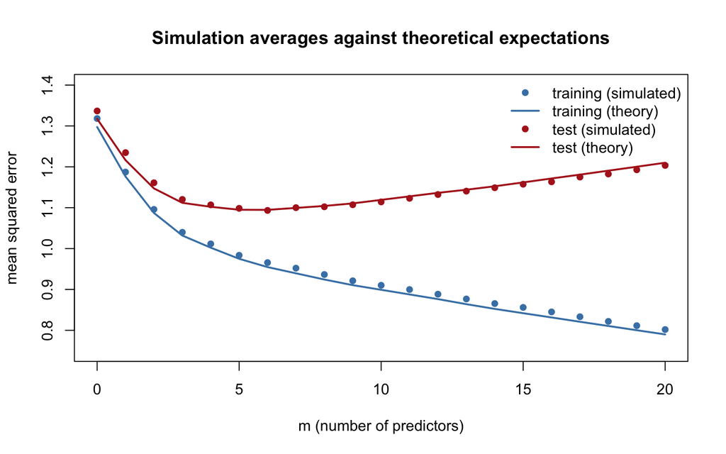

```r
plot(0:p, avg_test, type = "p", pch = 16, col = "firebrick", ylim = c(0.75, 1.40),
     xlab = "m (number of predictors)", ylab = "mean squared error",
     main = "Simulation averages against theoretical expectations")
points(0:p, avg_train, pch = 16, col = "steelblue")
lines(0:p, th_test,  col = "firebrick", lwd = 2)
lines(0:p, th_train, col = "steelblue", lwd = 2)
legend("topright", bty = "n",
       pch = c(16, NA, 16, NA), lty = c(NA, 1, NA, 1), lwd = 2,
       col = c("steelblue", "steelblue", "firebrick", "firebrick"),
       legend = c("training (simulated)", "training (theory)",
                  "test (simulated)", "test (theory)"))
```

The theoretical curves pass essentially through the simulated points. The largest gap is about $0.02$ for both curves, which is the size one should expect: the standard deviation of a single run’s test MSE is roughly $0.16$, so the standard error of an average over 200 runs is about $0.16/\sqrt{200} \approx 0.011$, and a discrepancy of $0.02$ is within about two standard errors.

The two formulas differ only in the sign of the term $(m+1)/n$. Both contain the same mean squared approximation bias $B_m^2/n$, which falls monotonically as predictors are added, from $0.307$ at $m = 0$ to essentially $0$ at $m = 20$. They also share the irreducible noise $\sigma^2 = 1$. The estimation-variance term $(m+1)/n$ is **subtracted** from the training error and **added** to the test error. Fitting $m+1$ coefficients lets the model absorb part of the training noise, which flatters the training error by exactly the amount by which it inflates the test error.

**(c) A single run, and why training error cannot select $m$.**

**Show the starter code**

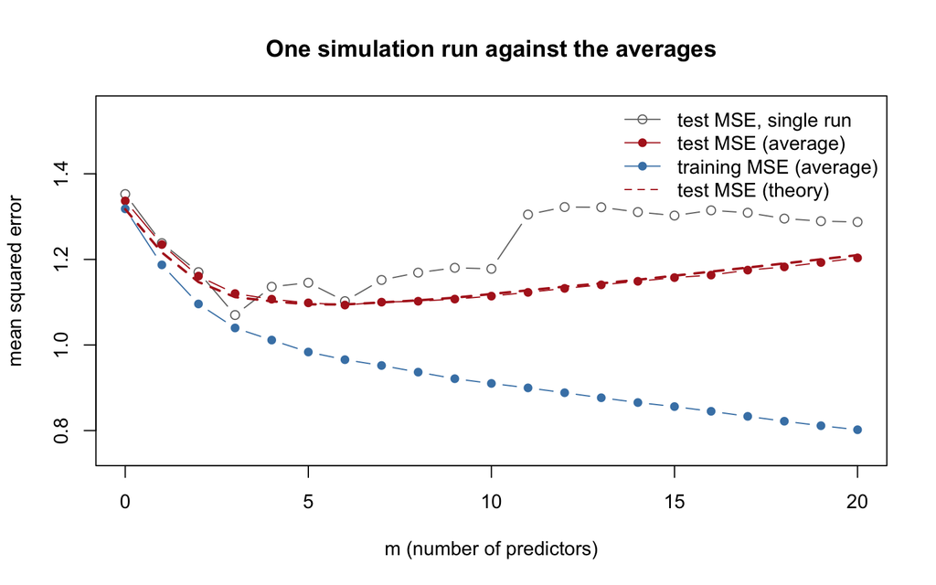

```r
plot(0:p, test[, 1], type = "b", pch = 1, col = "grey45", ylim = c(0.75, 1.55),
     xlab = "m (number of predictors)", ylab = "mean squared error",
     main = "One simulation run against the averages")
lines(0:p, avg_test,  type = "b", pch = 16, col = "firebrick")
lines(0:p, avg_train, type = "b", pch = 16, col = "steelblue")
lines(0:p, th_test, col = "firebrick", lwd = 2, lty = 2)
legend("topright", bty = "n", pch = c(1, 16, 16, NA), lty = c(1, 1, 1, 2),
       col = c("grey45", "firebrick", "steelblue", "firebrick"),
       legend = c("test MSE, single run", "test MSE (average)",
                  "training MSE (average)", "test MSE (theory)"))
```

**Show the starter code**

```r
c(argmin_single_run   = which.min(test[, 1]) - 1,
  argmin_average_test = which.min(avg_test)  - 1,
  argmin_theory_test  = which.min(th_test)   - 1,
  argmin_average_train = which.min(avg_train) - 1)
```

```
   argmin_single_run  argmin_average_test   argmin_theory_test
                   3                    6                    6
argmin_average_train
                  20
```

The single-run curve is visibly rougher than the average. It rests on one realized pair $(\boldsymbol\epsilon, \boldsymbol\epsilon^*)$, whereas each averaged point pools 200 independent pairs. Averaging divides the standard deviation by $\sqrt{200} \approx 14$, which is why one curve wanders by roughly $0.16$ while the average is smooth to about $0.011$. The wiggles are also correlated across $m$ rather than independent, because the same $\boldsymbol\epsilon^*$ is reused at every $m$ within a run; a test vector that happens to sit unusually close to the fitted values at one $m$ tends to do so at neighboring $m$ too, so the curve wanders in slow excursions instead of jittering independently.

The practical consequence is that the minimizer of one realized curve is unreliable. In this run the single-run test MSE is smallest at $m = 3$, while both the average and the theory place the optimum at $m = 6$. Choosing $m$ from a single small test set can be off by several predictors.

Training MSE cannot be used at all for this purpose. Its expectation is

$$E(\operatorname{MSE}_{\mathrm{train},m}\mid\mathbf X_{\mathrm{all}})
= \underbrace{\frac{B_m^2}{n}}_{\text{decreasing in } m}
+\;1\;
-\underbrace{\frac{m+1}{n}}_{\text{increasing in } m},$$

so **both** $m$-dependent terms push it downward. The bias term falls as more of $\boldsymbol\mu$ is captured, and the variance term is subtracted with a magnitude that grows with $m$. Expected training error is therefore decreasing in $m$ over the whole range, and its minimizer is always the largest model, $m = 20$, which the simulation confirms. The expected test error contains the same bias term but adds the variance penalty rather than subtracting it, so it decreases only while the bias reduction outweighs $1/n$ per extra coefficient and increases once it does not. That trade-off is what creates the minimum at $m = 6$ and is exactly the information training error discards. The gap between the two curves is the optimism, $2(m+1)/n$, which grows with model size and is precisely what Question 3 makes explicit.

## Question 2: Prediction error at one target point

Let $n=100$, $p=6$, and $\sigma^2=1$. Construct the fixed covariate matrix $\mathbf X_{\mathrm{all}}\in\mathbb R^{n\times p}$ with entries

$$(\mathbf X_{\mathrm{all}})_{ij}
=\sqrt{2}\cos\left\{
\frac{\pi j(i-\tfrac12)}{n}
\right\},
\qquad
i=1,\ldots,n,
\quad
j=1,\ldots,p.$$

Its columns satisfy

$$\mathbf 1^{\mathsf T}\mathbf X_{\mathrm{all}}=\mathbf 0^{\mathsf T},
\qquad
\frac{1}{n}\mathbf X_{\mathrm{all}}^{\mathsf T}\mathbf X_{\mathrm{all}}=\mathbf I_p.$$

Here $\mathbf I_p$ is the $p\times p$ identity matrix.

The following code shows a direct construction of $\mathbf X_{\mathrm{all}}$.

**R**

**Show the starter code**

```r
n <- 100
p <- 6
X_all <- outer(
  1:n, 1:p,
  function(i, j) sqrt(2) * cos(pi * j * (i - 0.5) / n)
)
```

**Python**

**Show the starter code**

```python
import numpy as np

n, p = 100, 6
i = np.arange(1, n + 1)[:, None]
j = np.arange(1, p + 1)[None, :]
X_all = np.sqrt(2) * np.cos(np.pi * j * (i - 0.5) / n)
```

Keep $\mathbf X_{\mathrm{all}}$ fixed and generate one training response from

$$\mathbf y
=\mathbf X_{\mathrm{all}}\boldsymbol\beta+\boldsymbol\epsilon,
\qquad
\boldsymbol\beta
=(0.5,0.5,0.5,0.5,0.5,0.5)^{\mathsf T},$$

where

$$\boldsymbol\epsilon
\sim
\mathcal N_n(\mathbf 0,\mathbf I_n).$$

Here $\mathbf I_n$ is the $n\times n$ identity matrix.

For $m=0,\ldots,p$, fit a linear model with an intercept and the first $m$ predictors. Consider prediction of the mean response at

$$\mathbf x_0=(0,1,0,0,1,0)^{\mathsf T}.$$

Write

$$\mu_0=\mathbf x_0^{\mathsf T}\boldsymbol\beta,$$

and let $\widehat\mu_{0,m}$ be the prediction from the model containing the first $m$ predictors. Here $x_{0j}$ denotes the $j$th coordinate of $\mathbf x_0$. For this design,

$$E\!\left[
\left(\widehat\mu_{0,m}-\mu_0\right)^2
\mid \mathbf X_{\mathrm{all}}
\right]
=
\left(
\sum_{j=m+1}^{p}x_{0j}\beta_j
\right)^2
+\frac{\sigma^2}{n}
\left(
1+\sum_{j=1}^{m}x_{0j}^2
\right).$$

1. Calculate $\mu_0$, the theoretical squared bias, and the expected squared error for $m=0,\ldots,p$ using the formula above. **You do not need to derive the formula.** Briefly explain in words why it consists of a squared bias term from omitted predictors and a variance term from estimating coefficients; no proof is required. Identify the values of $m$ where the expected squared error changes and where it remains unchanged.
2. Use seed `43203`. Generate the response, fit the models, and calculate

$$\left(\widehat\mu_{0,m}-\mu_0\right)^2.$$

Repeat this independently 200 times. Plot the simulation averages and theoretical expectations together. Report the smallest $m$ that minimizes the theoretical error.

3. All six regression coefficients are nonzero. Explain why only predictors 2 and 5 contribute directly to the mean response at $\mathbf x_0$. Contrast this target-specific error with the test MSE averaged over all rows of $\mathbf X_{\mathrm{all}}$ in Question 1.

### Answer

**Show the starter code**

```r
n <- 100
p <- 6
sigma2 <- 1

X_all <- outer(1:n, 1:p, function(i, j) sqrt(2) * cos(pi * j * (i - 0.5) / n))

beta <- rep(0.5, p)
x0   <- c(0, 1, 0, 0, 1, 0)

# the two stated design properties
c(max_abs_col_sum = max(abs(colSums(X_all))),
  max_dev_from_I  = max(abs(crossprod(X_all) / n - diag(p))))
```

```
max_abs_col_sum  max_dev_from_I
   1.532108e-14    4.440892e-16
```

**(a) Theoretical bias, variance, and expected error.**

**Show the starter code**

```r
mu0 <- sum(x0 * beta)
mu0
```

```
[1] 1
```

**Show the starter code**

```r
bias2 <- sapply(0:p, function(m)
  (if (m < p) sum(x0[(m + 1):p] * beta[(m + 1):p]) else 0)^2)

variance <- sapply(0:p, function(m)
  sigma2 / n * (1 + if (m >= 1) sum(x0[1:m]^2) else 0))

theory <- data.frame(m = 0:p, bias2 = bias2, variance = variance,
                     expected = bias2 + variance)
theory
```

```
  m bias2 variance expected
1 0  1.00     0.01     1.01
2 1  1.00     0.01     1.01
3 2  0.25     0.02     0.27
4 3  0.25     0.02     0.27
5 4  0.25     0.02     0.27
6 5  0.00     0.03     0.03
7 6  0.00     0.03     0.03
```

| $m$ | squared bias | variance | expected squared error |
| --- | --- | --- | --- |
| 0 | 1.00 | 0.01 | 1.01 |
| 1 | 1.00 | 0.01 | 1.01 |
| 2 | 0.25 | 0.02 | 0.27 |
| 3 | 0.25 | 0.02 | 0.27 |
| 4 | 0.25 | 0.02 | 0.27 |
| 5 | 0.00 | 0.03 | 0.03 |
| 6 | 0.00 | 0.03 | 0.03 |

Here $\mu_0 = \mathbf x_0^{\mathsf T}\boldsymbol\beta = 0.5 + 0.5 = 1$, since only the second and fifth coordinates of $\mathbf x_0$ are nonzero.

The first term is a **squared bias from omitted predictors**. A model holding only the first $m$ predictors has no coefficient at all for predictors $m+1,\ldots,p$, so the part of the target mean they contribute, $\sum_{j>m}x_{0j}\beta_j$, is simply absent from the prediction. That shortfall is the same in every repetition, so it is a systematic error rather than a fluctuation, and it enters squared.

The second term is an **estimation variance**. The prediction is $\widehat\mu_{0,m} = \widehat\beta_0 + \sum_{j\le m}x_{0j}\widehat\beta_j$, a linear combination of estimated coefficients with weights $(1, x_{01},\ldots,x_{0m})$. Because the design is orthogonal with $\mathbf X^{\mathsf T}\mathbf X/n = \mathbf I_p$, each coefficient is estimated independently with variance $\sigma^2/n$, so the variances add with squared weights, giving $(\sigma^2/n)(1 + \sum_{j\le m}x_{0j}^2)$. The leading $1$ is the intercept’s contribution.

The expected error **changes only at $m = 2$ and $m = 5$**, dropping from $1.01$ to $0.27$ and then from $0.27$ to $0.03$. It is **unchanged at $m = 1, 3, 4$, and $6$**. Those are exactly the steps that admit predictors $1, 3, 4, 6$, the ones whose coordinate in $\mathbf x_0$ is zero. Such a predictor adds nothing to the bias term, since its contribution $x_{0j}\beta_j$ is already zero, and nothing to the variance term either, since it enters that sum as $x_{0j}^2 = 0$. At this particular target point those predictors are free: they neither help nor hurt.

**(b) Simulation.**

**Show the starter code**

```r
set.seed(43203)
nsim <- 200

err <- matrix(NA_real_, p + 1, nsim)
for (s in 1:nsim) {
  y <- as.vector(X_all %*% beta) + rnorm(n)
  for (m in 0:p) {
    Xm <- if (m == 0) matrix(1, n, 1) else cbind(1, X_all[, 1:m, drop = FALSE])
    bh <- qr.coef(qr(Xm), y)
    pred <- if (m == 0) bh[1] else bh[1] + sum(bh[-1] * x0[1:m])
    err[m + 1, s] <- (pred - mu0)^2
  }
}

avg <- rowMeans(err)
round(data.frame(m = 0:p, simulated = avg,
                 theoretical = theory$expected,
                 difference = avg - theory$expected), 5)
```

```
  m simulated theoretical difference
1 0   1.01892        1.01    0.00892
2 1   1.01892        1.01    0.00892
3 2   0.26712        0.27   -0.00288
4 3   0.26712        0.27   -0.00288
5 4   0.26712        0.27   -0.00288
6 5   0.03376        0.03    0.00376
7 6   0.03376        0.03    0.00376
```

**Show the starter code**

```r
# smallest m attaining the theoretical minimum
(0:p)[which.min(theory$expected)]
```

```
[1] 5
```

**Show the starter code**

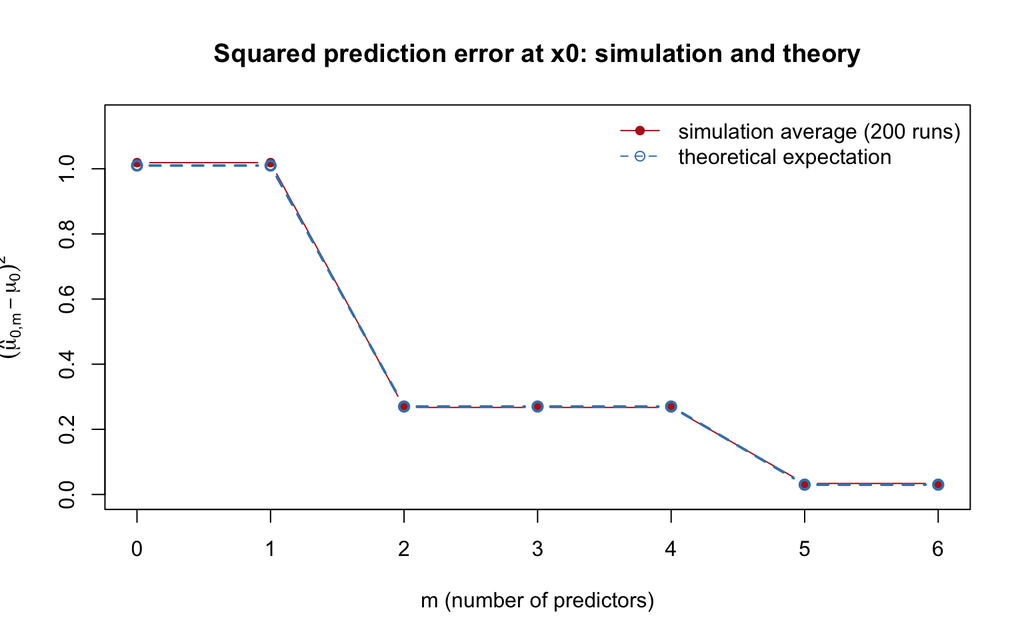

```r
plot(0:p, avg, type = "b", pch = 16, col = "firebrick", ylim = c(0, 1.15),
     xlab = "m (number of predictors)",
     ylab = expression((hat(mu)[0*","*m] - mu[0])^2),
     main = "Squared prediction error at x0: simulation and theory")
lines(0:p, theory$expected, type = "b", pch = 1, lty = 2, lwd = 2, col = "steelblue")
legend("topright", bty = "n", pch = c(16, 1), lty = c(1, 2),
       col = c("firebrick", "steelblue"),
       legend = c("simulation average (200 runs)", "theoretical expectation"))
```

The simulation averages sit on top of the theoretical values, with discrepancies of at most about $0.009$, well inside Monte Carlo error for 200 runs. The **smallest $m$ minimizing the theoretical error is $m = 5$**, with expected error $0.03$; $m = 6$ ties it exactly but uses one more predictor.

The simulated values are not merely close within each block, they are **identical**: every run gives the same error at $m = 0$ and $m = 1$, the same at $m = 2, 3, 4$, and the same at $m = 5, 6$. This is exact rather than approximate. Because the design is orthogonal, $\widehat\beta_j = \frac{1}{n}\mathbf x_j^{\mathsf T}\mathbf y$ does not change when other predictors enter the model, so admitting predictor $j$ changes the prediction at $\mathbf x_0$ by exactly $x_{0j}\widehat\beta_j$. When $x_{0j} = 0$ that change is zero in every realization, not merely zero on average.

**(c) Why only predictors 2 and 5 matter here.**

All six coefficients equal $0.5$ and none is zero, so every predictor genuinely affects the response somewhere in the data. But the target mean at this particular point is

$$\mu_0 = \mathbf x_0^{\mathsf T}\boldsymbol\beta = \sum_{j=1}^{6} x_{0j}\beta_j,$$

and each coefficient enters weighted by the corresponding coordinate of $\mathbf x_0$. With $\mathbf x_0 = (0,1,0,0,1,0)^{\mathsf T}$, the coefficients $\beta_1, \beta_3, \beta_4, \beta_6$ are multiplied by zero. They matter for the response at other points in the design, but they contribute nothing to the mean response *here*. Relevance is a property of the pair (coefficient, target point), not of the coefficient alone.

The contrast with Question 1 is the essential point. There the criterion was test MSE averaged over **all $n$ rows** of $\mathbf X_{\mathrm{all}}$, so every predictor was weighted by how much it varies across the whole design. Each additional coefficient cost a fixed $\sigma^2/n$ of variance regardless of which predictor it was, giving the uniform penalty $(m+1)/n$ and the familiar U-shaped curve with a single interior optimum.

Here the criterion is fixed at one point, so the cost and benefit of a predictor both depend on $\mathbf x_0$. Predictors with $x_{0j} = 0$ are neither useful nor costly, which is why the curve is a staircase with flat stretches rather than a smooth U. A model can therefore be excellent for one target and mediocre on average, or vice versa. A single aggregate error number can hide this entirely: averaging over the design answers “how does this model do overall,” which is a different question from “how does this model do for the case in front of me.”

## Question 3: The optimism correction

Choose one candidate model before observing the response. Let $p$ be its number of predictors and let $\mathbf X\in\mathbb R^{n\times(p+1)}$ be its full-rank design matrix, including the intercept. The model has $p+1$ fitted coefficients. Let

$$\mathbf H
=\mathbf X
(\mathbf X^{\mathsf T}\mathbf X)^{-1}
\mathbf X^{\mathsf T}$$

be its hat matrix. Suppose

$$\mathbf y=\boldsymbol\mu+\boldsymbol\epsilon,
\qquad
\mathbf y^*=\boldsymbol\mu+\boldsymbol\epsilon^*,$$

Conditional on the fixed design $\mathbf X$, the two error vectors are independent, have mean zero, and have covariance matrix $\sigma^2\mathbf I_n$. Define

$$\operatorname{MSE}_{\mathrm{train}}
=
\frac{1}{n}
\left\lVert
\mathbf y-\mathbf H\mathbf y
\right\rVert_2^2,
\qquad
\operatorname{MSE}_{\mathrm{test}}
=
\frac{1}{n}
\left\lVert
\mathbf y^*-\mathbf H\mathbf y
\right\rVert_2^2.$$

The conditional bias vector of the fitted mean is

$$E(\mathbf H\mathbf y\mid\mathbf X)-\boldsymbol\mu
=
-(\mathbf I_n-\mathbf H)\boldsymbol\mu.$$

Let $B^2$ denote the **total squared approximation bias**:

$$B^2
=\left\lVert
(\mathbf I_n-\mathbf H)\boldsymbol\mu
\right\rVert_2^2.$$

Thus, $B^2/n$ is the mean squared approximation bias.

You may use

$$\mathbf H^{\mathsf T}=\mathbf H,
\qquad
\mathbf H^2=\mathbf H,
\qquad
\operatorname{tr}(\mathbf H)=p+1.$$

For any fixed matrix $\mathbf A$, you may also use

$$E\!\left(
\boldsymbol\epsilon^{\mathsf T}
\mathbf A
\boldsymbol\epsilon
\mid \mathbf X
\right)
=\sigma^2\operatorname{tr}(\mathbf A).$$

1. Derive

$$E(\operatorname{MSE}_{\mathrm{train}}\mid\mathbf X)
=\frac{B^2}{n}
+\sigma^2\left(1-\frac{p+1}{n}\right),$$

and

$$E(\operatorname{MSE}_{\mathrm{test}}\mid\mathbf X)
=\frac{B^2}{n}
+\sigma^2\left(1+\frac{p+1}{n}\right).$$

2. Deduce the expected optimism, defined as $E(\operatorname{MSE}_{\mathrm{test}}-\operatorname{MSE}_{\mathrm{train}}\mid\mathbf X)$. For

$$n=120,
\qquad
p=4,
\qquad
\frac{B^2}{n}=0.04,
\qquad
\sigma^2=1,$$

calculate the expected training MSE, expected test MSE, and their difference. Explain why the ordering need not hold for every realized pair of responses.

3. Continue with $n=120$ and $p=4$. Suppose the candidate model has residual sum of squares $\operatorname{RSS}=116.4$, and suppose a common estimate of the error variance is $\widehat\sigma^2=0.96$.

Calculate

$$\widehat{\operatorname{MSE}}_{\mathrm{test}}
=\frac{
\operatorname{RSS}+2(p+1)\widehat\sigma^2
}{n},$$

and

$$C_p
=\frac{\operatorname{RSS}}{\widehat\sigma^2}
-n+2(p+1).$$

Show how these two quantities are related, and explain why minimizing $C_p$ is equivalent to minimizing the corrected test MSE when $n$ and $\widehat\sigma^2$ are common to all candidate models.

### Answer

**(a) Derivation of the two expectations.**

*Training error.* The residual vector is

$$\mathbf y - \mathbf H\mathbf y
= (\mathbf I - \mathbf H)\mathbf y
= (\mathbf I - \mathbf H)\boldsymbol\mu + (\mathbf I - \mathbf H)\boldsymbol\epsilon .$$

Expanding the squared norm,

$$\lVert \mathbf y - \mathbf H\mathbf y\rVert_2^2
= \lVert(\mathbf I - \mathbf H)\boldsymbol\mu\rVert_2^2
+ 2\,\boldsymbol\mu^{\mathsf T}(\mathbf I - \mathbf H)^{\mathsf T}(\mathbf I - \mathbf H)\boldsymbol\epsilon
+ \boldsymbol\epsilon^{\mathsf T}(\mathbf I - \mathbf H)^{\mathsf T}(\mathbf I - \mathbf H)\boldsymbol\epsilon .$$

Since $\mathbf H$ is symmetric and idempotent, so is $\mathbf I - \mathbf H$, giving $(\mathbf I - \mathbf H)^{\mathsf T}(\mathbf I - \mathbf H) = \mathbf I - \mathbf H$. The first term is $B^2$ by definition. The cross term has expectation zero because $E(\boldsymbol\epsilon\mid\mathbf X) = \mathbf 0$. For the quadratic term,

$$E\!\left(\boldsymbol\epsilon^{\mathsf T}(\mathbf I - \mathbf H)\boldsymbol\epsilon \mid \mathbf X\right)
= \sigma^2\operatorname{tr}(\mathbf I - \mathbf H)
= \sigma^2\left(n - (p+1)\right).$$

Therefore

$$E\!\left(\operatorname{MSE}_{\mathrm{train}}\mid\mathbf X\right)
= \frac{1}{n}\left[B^2 + \sigma^2\left(n - (p+1)\right)\right]
= \frac{B^2}{n} + \sigma^2\left(1 - \frac{p+1}{n}\right).$$

*Test error.* Using $\mathbf y^* = \boldsymbol\mu + \boldsymbol\epsilon^*$ and $\mathbf H\mathbf y = \mathbf H\boldsymbol\mu + \mathbf H\boldsymbol\epsilon$,

$$\mathbf y^* - \mathbf H\mathbf y
= (\mathbf I - \mathbf H)\boldsymbol\mu + \boldsymbol\epsilon^* - \mathbf H\boldsymbol\epsilon .$$

Squaring gives three squared terms and three cross terms. Each cross term vanishes in expectation:

- $2\,\boldsymbol\mu^{\mathsf T}(\mathbf I - \mathbf H)\boldsymbol\epsilon^*$ has mean zero since $E(\boldsymbol\epsilon^*\mid\mathbf X) = \mathbf 0$;
- $-2\,\boldsymbol\mu^{\mathsf T}(\mathbf I - \mathbf H)\mathbf H\boldsymbol\epsilon$ is **identically** zero, because $(\mathbf I - \mathbf H)\mathbf H = \mathbf H - \mathbf H^2 = \mathbf 0$;
- $-2\,\boldsymbol\epsilon^{*\mathsf T}\mathbf H\boldsymbol\epsilon$ has mean zero because $\boldsymbol\epsilon$ and $\boldsymbol\epsilon^*$ are independent with mean zero.

For the remaining squared terms, $E(\lVert\boldsymbol\epsilon^*\rVert_2^2\mid\mathbf X) = \sigma^2 n$, and

$$E\!\left(\lVert\mathbf H\boldsymbol\epsilon\rVert_2^2\mid\mathbf X\right)
= E\!\left(\boldsymbol\epsilon^{\mathsf T}\mathbf H^{\mathsf T}\mathbf H\boldsymbol\epsilon\mid\mathbf X\right)
= \sigma^2\operatorname{tr}(\mathbf H)
= \sigma^2 (p+1),$$

using $\mathbf H^{\mathsf T}\mathbf H = \mathbf H^2 = \mathbf H$. Hence

$$E\!\left(\operatorname{MSE}_{\mathrm{test}}\mid\mathbf X\right)
= \frac{1}{n}\left[B^2 + \sigma^2 n + \sigma^2(p+1)\right]
= \frac{B^2}{n} + \sigma^2\left(1 + \frac{p+1}{n}\right).$$

The two results differ only in the sign of $\sigma^2(p+1)/n$. The same fitted noise component $\mathbf H\boldsymbol\epsilon$ is *subtracted* from the training error, because the fit has already chased that noise, and *added* to the test error, because the new response carries fresh noise that the fit cannot anticipate.

**(b) Expected optimism.**

Subtracting the two expressions, the bias term and the $\sigma^2$ term cancel:

$$E\!\left(\operatorname{MSE}_{\mathrm{test}} - \operatorname{MSE}_{\mathrm{train}}\mid\mathbf X\right)
= 2\sigma^2\,\frac{p+1}{n}.$$

The optimism does not involve $B^2$ at all: it depends only on the number of fitted coefficients, the noise level, and the sample size.

**Show the starter code**

```r
n <- 120; p <- 4; B2_over_n <- 0.04; sigma2 <- 1

E_train <- B2_over_n + sigma2 * (1 - (p + 1) / n)
E_test  <- B2_over_n + sigma2 * (1 + (p + 1) / n)

c(E_train = E_train, E_test = E_test,
  optimism = E_test - E_train,
  formula_check = 2 * sigma2 * (p + 1) / n)
```

```
      E_train        E_test      optimism formula_check
   0.99833333    1.08166667    0.08333333    0.08333333
```

With $n = 120$, $p = 4$, $B^2/n = 0.04$ and $\sigma^2 = 1$:

$$E(\operatorname{MSE}_{\mathrm{train}}) = 0.04 + \left(1 - \tfrac{5}{120}\right) = 0.9983,
\qquad
E(\operatorname{MSE}_{\mathrm{test}}) = 0.04 + \left(1 + \tfrac{5}{120}\right) = 1.0817,$$

with expected optimism $2(5)/120 = 0.0833$.

**Show the starter code**

```r
set.seed(1)
nsim <- 50000
X  <- cbind(1, matrix(rnorm(n * p), n, p))
Q  <- qr.Q(qr(X))
mu <- as.vector(Q %*% (t(Q) %*% rnorm(n)))          # any mu; B^2 plays no role here
gap <- replicate(nsim, {
  e  <- rnorm(n); es <- rnorm(n)
  y  <- mu + e;   ys <- mu + es
  yh <- Q %*% (t(Q) %*% y)
  mean((ys - yh)^2) - mean((y - yh)^2)
})
c(mean_gap = mean(gap), theoretical = 2 * (p + 1) / n,
  proportion_negative = mean(gap < 0))
```

```
           mean_gap         theoretical proportion_negative
         0.08264276          0.08333333          0.32914000
```

Roughly a third of individual runs show a negative gap, even though the average matches the theoretical $0.0833$ closely.

**(c) Relating the corrected test MSE to $C_p$.**

**Show the starter code**

```r
n <- 120; p <- 4
RSS <- 116.4; sigma2_hat <- 0.96

mse_test_hat <- (RSS + 2 * (p + 1) * sigma2_hat) / n
Cp           <- RSS / sigma2_hat - n + 2 * (p + 1)

c(mse_test_hat = mse_test_hat, Cp = Cp,
  identity_check = sigma2_hat + (sigma2_hat / n) * Cp)
```

```
  mse_test_hat             Cp identity_check
          1.05          11.25           1.05
```

$$\widehat{\operatorname{MSE}}_{\mathrm{test}}
= \frac{116.4 + 2(5)(0.96)}{120}
= \frac{126}{120}
= 1.05,
\qquad
C_p = \frac{116.4}{0.96} - 120 + 10 = 11.25 .$$

The two are the same quantity on different scales. Multiplying $C_p$ by $\widehat\sigma^2/n$,

$$\frac{\widehat\sigma^2}{n}C_p
= \frac{\operatorname{RSS}}{n} - \widehat\sigma^2 + \frac{2(p+1)\widehat\sigma^2}{n}
= \widehat{\operatorname{MSE}}_{\mathrm{test}} - \widehat\sigma^2 ,$$

so that

$$\widehat{\operatorname{MSE}}_{\mathrm{test}}
= \widehat\sigma^2 + \frac{\widehat\sigma^2}{n}\,C_p .$$

Numerically, $0.96 + (0.96/120)(11.25) = 0.96 + 0.09 = 1.05$, matching exactly.

This is an increasing affine transformation: the intercept $\widehat\sigma^2$ and the slope $\widehat\sigma^2/n = 0.008$ are both **positive** and, crucially, both depend only on $n$ and $\widehat\sigma^2$, which are held common across all candidate models by construction. An increasing affine map preserves order, so for any two candidates, $C_p^{(1)} < C_p^{(2)}$ if and only if $\widehat{\operatorname{MSE}}^{(1)}_{\mathrm{test}} < \widehat{\operatorname{MSE}}^{(2)}_{\mathrm{test}}$. Minimizing either criterion selects the same model. Note this equivalence would fail if $\widehat\sigma^2$ were re-estimated separately within each candidate model, since the slope and intercept would then vary from model to model; estimating it once from the full reference model is what makes the comparison legitimate.

## Question 4: Comparing Mallows’ $C_p$, AIC, and BIC

Use `data/diabetes.csv`, with `y` as the response. Use rows 1 through 370 as the training data, and let $n=370$ denote the training sample size. Do not use rows 371 through 442 in this question. Fit the following ordinary least-squares models, each with an intercept.

| Model | Predictors | $p$ |
| --- | --- | --- |
| Model A | `bmi`, `bp`, `s5`, `sex`, `s1`, `s2`, `s4` | 7 |
| Model B | all predictors in Model A, followed by `s6` | 8 |
| Full reference | all ten predictors | 10 |

Here $p$ counts predictors, so each model has $p+1$ fitted coefficients including the intercept. Estimate one common noise variance from the full reference model, using $p=10$:

$$\widehat\sigma^2
=\frac{\operatorname{RSS}_{\mathrm{full}}}{n-(p+1)}.$$

For Models A and B, calculate

$$C_p
=\frac{\operatorname{RSS}}{\widehat\sigma^2}
-n+2(p+1),$$

$$\operatorname{AIC}^{\mathrm{red}}
=n\log\left(\frac{\operatorname{RSS}}{n}\right)+2(p+1),$$

and

$$\operatorname{BIC}^{\mathrm{red}}
=n\log\left(\frac{\operatorname{RSS}}{n}\right)
+(p+1)\log(n).$$

The reduced AIC and BIC omit constants shared by the two candidate models. Smaller values are preferred within each criterion.

1. Fit the three models. Report $p$, RSS, the residual degrees of freedom of the full model, and $\widehat\sigma^2$.
2. Calculate $C_p$, reduced AIC, and reduced BIC for Models A and B. State which model each criterion selects. Do not compare numerical values across different criteria.
3. Compare the improvement in fit from adding `s6` with the one-parameter penalty under each criterion. Use this comparison to explain any disagreement. Why does selecting a model not establish that it is the true data-generating model?

### Answer

**(a) Fitting the three models.**

**Show the starter code**

```r
diabetes <- read.csv("data/diabetes.csv")
train <- diabetes[1:370, ]
n <- 370

fit_A    <- lm(y ~ bmi + bp + s5 + sex + s1 + s2 + s4, data = train)
fit_B    <- lm(y ~ bmi + bp + s5 + sex + s1 + s2 + s4 + s6, data = train)
fit_full <- lm(y ~ ., data = train)

RSS_A    <- sum(resid(fit_A)^2)
RSS_B    <- sum(resid(fit_B)^2)
RSS_full <- sum(resid(fit_full)^2)

df_full    <- df.residual(fit_full)          # n - (10 + 1)
sigma2_hat <- RSS_full / df_full

data.frame(
  model    = c("A", "B", "Full reference"),
  p        = c(7, 8, 10),
  coefs    = c(8, 9, 11),
  RSS      = c(RSS_A, RSS_B, RSS_full),
  row.names = NULL
)
```

```
           model  p coefs     RSS
1              A  7     8 1098909
2              B  8     9 1089717
3 Full reference 10    11 1089452
```

**Show the starter code**

```r
c(full_residual_df = df_full, sigma2_hat = sigma2_hat)
```

```
full_residual_df       sigma2_hat
         359.000         3034.684
```

| model | $p$ | coefficients | RSS |
| --- | --- | --- | --- |
| Model A | 7 | 8 | 1,098,909 |
| Model B | 8 | 9 | 1,089,717 |
| Full reference | 10 | 11 | 1,089,452 |

The full model has residual degrees of freedom $n - (p+1) = 370 - 11 = 359$, giving

$$\widehat\sigma^2 = \frac{1{,}089{,}452}{359} = 3034.68 .$$

Note how little the full model improves on Model B: an RSS drop of only about 265 for two extra predictors. Almost all of the explanatory power sits in the seven predictors of Model A.

**(b) The three criteria.**

**Show the starter code**

```r
Cp_stat  <- function(RSS, p) RSS / sigma2_hat - n + 2 * (p + 1)
AIC_red  <- function(RSS, p) n * log(RSS / n) + 2 * (p + 1)
BIC_red  <- function(RSS, p) n * log(RSS / n) + (p + 1) * log(n)

criteria <- data.frame(
  p      = c(7, 8),
  RSS    = c(RSS_A, RSS_B),
  Cp     = c(Cp_stat(RSS_A, 7), Cp_stat(RSS_B, 8)),
  AICred = c(AIC_red(RSS_A, 7),  AIC_red(RSS_B, 8)),
  BICred = c(BIC_red(RSS_A, 7),  BIC_red(RSS_B, 8)),
  row.names = c("Model A", "Model B")
)
round(criteria, 4)
```

```
        p     RSS     Cp   AICred   BICred
Model A 7 1098909 8.1163 2974.640 3005.948
Model B 8 1089717 7.0874 2973.532 3008.754
```

**Show the starter code**

```r
c(Cp_selects  = rownames(criteria)[which.min(criteria$Cp)],
  AIC_selects = rownames(criteria)[which.min(criteria$AICred)],
  BIC_selects = rownames(criteria)[which.min(criteria$BICred)])
```

```
 Cp_selects AIC_selects BIC_selects
  "Model B"   "Model B"   "Model A"
```

|  | $p$ | $C_p$ | $\operatorname{AIC}^{\mathrm{red}}$ | $\operatorname{BIC}^{\mathrm{red}}$ |
| --- | --- | --- | --- | --- |
| Model A | 7 | 8.116 | 2974.640 | **3005.948** |
| Model B | 8 | **7.087** | **2973.532** | 3008.754 |

$C_p$ selects **Model B**. Reduced AIC selects **Model B**. Reduced BIC selects **Model A**. Comparisons are made only within a criterion, never across them; the three columns are on different scales and their absolute values are not comparable.

**(c) Why the criteria disagree.**

**Show the starter code**

```r
fit_gain   <- RSS_A - RSS_B                       # raw RSS improvement from s6
gain_Cp    <- fit_gain / sigma2_hat               # same gain in Cp units
gain_loglik <- n * log(RSS_B / n) - n * log(RSS_A / n)   # in AIC/BIC units

c(RSS_drop            = fit_gain,
  gain_in_Cp_units    = gain_Cp,        Cp_penalty  = 2,
  gain_in_loglik_units = gain_loglik,   AIC_penalty = 2,
  BIC_penalty         = log(n))
```

```
            RSS_drop     gain_in_Cp_units           Cp_penalty
         9191.508850             3.028819             2.000000
gain_in_loglik_units          AIC_penalty          BIC_penalty
           -3.107775             2.000000             5.913503
```

**Show the starter code**

```r
# net change in each criterion when s6 is added (negative favours Model B)
c(delta_Cp  = criteria["Model B", "Cp"]     - criteria["Model A", "Cp"],
  delta_AIC = criteria["Model B", "AICred"] - criteria["Model A", "AICred"],
  delta_BIC = criteria["Model B", "BICred"] - criteria["Model A", "BICred"])
```

```
 delta_Cp delta_AIC delta_BIC
-1.028819 -1.107775  2.805728
```

Adding `s6` reduces RSS by $9{,}191.5$. Every criterion sees the *same* improvement in fit; they differ only in what they charge for the extra parameter.

- In $C_p$ units the gain is $9{,}191.5 / 3034.68 = 3.03$, against a penalty of $2$. Net change $-1.03$, so **B wins**.
- In AIC units the gain is $n\log(\mathrm{RSS}_B/n) - n\log(\mathrm{RSS}_A/n) = -3.11$, against a penalty of $+2$. Net change $-1.11$, so **B wins**.
- BIC sees the identical fit gain of $-3.11$ but charges $\log(370) = 5.91$. Net change $+2.81$, so **A wins**.

The disagreement is therefore entirely a matter of price, not of evidence. The improvement from `s6` is worth about 3 units on this scale. That clears the AIC and $C_p$ threshold of 2 but falls well short of BIC’s threshold of $5.91$. Since $\log n > 2$ whenever $n > e^2 \approx 7.4$, BIC is more conservative than AIC at any realistic sample size, and increasingly so as $n$ grows. The two criteria are built for different goals: $C_p$ and AIC estimate out-of-sample prediction error and will happily accept a predictor that helps prediction slightly, whereas BIC approximates a posterior model probability and demands stronger evidence before enlarging the model.

The evidence for `s6` is genuinely marginal, which is why the criteria can split at all. Its coefficient has a $p$-value of about $0.082$ in Model B, and the winning margins are around one unit in both $C_p$ and AIC. A different 370-row sample could easily reverse them.

**Why selecting a model does not establish that it is the true one.**

A selection criterion only ranks the candidates it is given. Here that set has two members, and the better of two is not thereby correct: the true relationship might involve a predictor in neither model, a nonlinear term, or an interaction, and nothing in the comparison could reveal it. The criteria also assume the linear-Gaussian framework itself, so if the mean is not linear in these covariates or the errors are heteroskedastic, the “true data-generating model” is not in the candidate set at all and the exercise is choosing the least-bad approximation.

Beyond that, each criterion is a *statistic* computed from one finite sample, so it carries sampling variability. RSS is random, so $C_p$, AIC, and BIC are random, and their ordering is random too. With margins near one unit, the ranking here is not stable evidence about the world. The criteria also target different things: $C_p$ and AIC aim at prediction accuracy and are known not to be consistent for model identification, tending to retain unnecessary predictors even as $n \to \infty$, while BIC is consistent but only under the assumption that the true model is among the candidates. Selecting a model answers “which of these performs best by this measure on this data,” which is a much weaker claim than “this is how the data were generated.”

## Question 5: Validation and final test data

Use rows 1 through 370 of `diabetes.csv` as the training data and rows 371 through 442 as the final test data. Consider eleven nested candidate models. For $m=0,1,\ldots,10$, the model with $m$ predictors contains an intercept and the first $m$ predictors in this order:

`age`, `sex`, `bmi`, `bp`, `s1`, `s2`, `s3`, `s4`, `s5`, `s6`.

An analyst proposes the following procedure:

1. Fit all eleven candidate models using the training data.
2. Calculate the MSE of each model on the final test data.
3. Select the model with the smallest test MSE.
4. Report that minimum as the final estimate of prediction error.

The analyst argues that the procedure is valid because the final test data were not used to estimate the regression coefficients.

1. Identify the first step that misuses the final test data. Explain why the minimum of eleven test MSE values is generally too favorable as an estimate of the selected procedure’s future prediction error.
2. Rewrite the analysis using five-fold cross-validation within the training data. State how the predictor count is selected, what is refitted, and when the final test data may be used.
3. Suppose the analyst has already examined all eleven test MSE values. What can still be reported transparently, and what additional data would be needed for a new final evaluation?

### Answer

**Show the starter code**

```r
predictor_order <- c("age", "sex", "bmi", "bp", "s1",
                     "s2", "s3", "s4", "s5", "s6")

train_set <- diabetes[1:370, ]
test_set  <- diabetes[371:442, ]

fit_m <- function(dat, m) {
  if (m == 0) lm(y ~ 1, data = dat)
  else lm(as.formula(paste("y ~", paste(predictor_order[1:m], collapse = " + "))),
          data = dat)
}
mse_on <- function(model, dat) mean((dat$y - as.vector(predict(model, newdata = dat)))^2)
```

**(a) The first step that misuses the final test data.**

The misuse begins at **step 3**, where the test MSE values are used to *choose* the predictor count. Steps 1 and 2 are mechanically fine, and step 2 on its own is only a computation. The moment those eleven numbers determine which model is adopted, the test data have entered the modeling procedure. Step 4 then compounds the error by reporting the minimum of the same eleven numbers as the estimate of future performance.

The analyst’s defense is that the test data were not used to estimate the regression coefficients. That is true and beside the point. Choosing $m$ is a fitted decision just as much as choosing $\widehat{\boldsymbol\beta}$ is; it is simply a discrete parameter selected by minimizing error on the test set. Once the test set has selected something, it is no longer independent of the model being evaluated, and it cannot serve as an unbiased yardstick for that model.

**Show the starter code**

```r
analyst_test_mse <- sapply(0:10, function(m) mse_on(fit_m(train_set, m), test_set))
round(setNames(analyst_test_mse, 0:10), 1)
```

```
     0      1      2      3      4      5      6      7      8      9     10
5822.9 5527.8 5527.2 3719.2 3246.8 3234.9 3207.6 2636.5 2624.9 2369.3 2484.8
```

**Show the starter code**

```r
c(analyst_selects_m = (0:10)[which.min(analyst_test_mse)],
  analyst_reports   = min(analyst_test_mse))
```

```
analyst_selects_m   analyst_reports
            9.000          2369.344
```

The minimum of eleven values is systematically too favorable. Each test MSE equals the model’s true prediction error plus a random error, since it is an average over only 72 observations. Taking a minimum selects partly on genuine quality and partly on *favorable noise*: whichever model happened to suit this particular test set is the one that wins. In expectation the minimum of several noisy estimates lies below the smallest true error, so the reported figure is biased downward — the winner’s curse. The following simulation makes the size of the effect concrete, using the eleven cross-validated errors below as stand-ins for the true errors:

**Show the starter code**

```r
set.seed(43205)
true_err <- c(5988, 5805, 5842, 3974, 3735, 3751, 3797, 3267, 3283, 3154, 3134)
n_test <- 72

sim <- replicate(20000, {
  observed <- true_err * (1 + sqrt(2 / n_test) * rnorm(11))   # noisy test MSEs
  k <- which.min(observed)
  c(reported = observed[k], true_error_of_choice = true_err[k])
})

c(best_attainable_true_error = min(true_err),
  mean_reported_minimum      = mean(sim["reported", ]),
  mean_true_error_of_choice  = mean(sim["true_error_of_choice", ]),
  P_reported_below_best_true = mean(sim["reported", ] < min(true_err)),
  P_picks_truly_best_model   = mean(sim["true_error_of_choice", ] == min(true_err)))
```

```
best_attainable_true_error      mean_reported_minimum
                 3134.0000                  2588.0827
 mean_true_error_of_choice P_reported_below_best_true
                 3322.4803                     0.9523
  P_picks_truly_best_model
                    0.2396
```

The reported minimum averages about $2588$ while the best error actually attainable is $3134$, and in roughly $95\%$ of repetitions the reported number falls below the error of the *best possible* model — an estimate that is not merely optimistic but impossible. At the same time the procedure identifies the genuinely best model only about a quarter of the time, and the model it does pick has an average true error of about $3323$, worse than the best available. The analyst thus tends to choose a slightly inferior model and to attach to it an error estimate that is far too low.

**(b) The analysis rewritten with five-fold cross-validation.**

**Show the starter code**

```r
set.seed(43204)
K <- 5
folds <- sample(rep(1:K, length.out = nrow(train_set)))

cv_mse <- sapply(0:10, function(m) {
  mean(sapply(1:K, function(k) {
    model <- fit_m(train_set[folds != k, ], m)          # fit on K-1 folds
    mse_on(model, train_set[folds == k, ])              # score the held-out fold
  }))
})
round(setNames(cv_mse, 0:10), 1)
```

```
     0      1      2      3      4      5      6      7      8      9     10
5988.4 5804.7 5841.9 3974.1 3734.9 3751.1 3796.6 3266.7 3283.3 3153.8 3133.8
```

**Show the starter code**

```r
m_star <- (0:10)[which.min(cv_mse)]
final_model <- fit_m(train_set, m_star)                 # refit on ALL training rows
final_test_mse <- mse_on(final_model, test_set)         # test data touched exactly once

c(m_star = m_star, final_test_mse = final_test_mse)
```

```
        m_star final_test_mse
        10.000       2484.776
```

The corrected procedure is as follows.

*How the predictor count is selected.* Split the 370 **training** rows into five folds. For each $m = 0,\ldots,10$ and each fold $k$, fit the model on the other four folds and record the MSE on fold $k$. Average the five values to obtain $\operatorname{CV}_m$, and take $m^\star = \arg\min_m \operatorname{CV}_m$. Every quantity here comes from the training data; the final test set plays no part.

*What is refitted.* Having chosen $m^\star$, discard the fold-specific fits — they exist only to estimate error — and refit the model with the first $m^\star$ predictors on all 370 training rows. That single refitted model is the deliverable.

*When the final test data may be used.* Exactly once, at the very end, to evaluate the one model already selected. Because nothing about $m^\star$ or the coefficients depended on those 72 rows, the resulting MSE is an unbiased estimate of that model’s prediction error. The moment one looks at the answer and reconsiders the model, that guarantee is gone.

Here cross-validation selects $m^\star = 10$ and the honest test MSE is $2484.8$, whereas the analyst selected $m = 9$ and reported $2369.3$. The analyst’s figure is the smaller of the two, which is exactly the direction the winner’s curse predicts.

**(c) What can still be reported after the test data have been examined.**

The examined values have not become worthless; they simply cannot be presented as an unbiased estimate of future performance. What remains honest to report:

- the full table of all eleven test MSEs, together with the explicit statement that the model was selected by minimizing over them, so a reader can see the selection effect rather than being shown only its winner;
- the cross-validated error curve computed within the training data, which was never contaminated and remains a legitimate basis for choosing $m$ and for estimating error;
- the fitted model itself, its coefficients, and standard diagnostics, none of which are invalidated by how the test set was used;
- a description of the analysis path actually taken, including that eleven models were compared on the test data, which is what allows the optimism to be judged.

What cannot be reported is the minimum of those eleven values as *the* estimate of prediction error for the selected model.

For a genuinely new final evaluation, more data are required: a fresh sample of observations that played no role in fitting the coefficients, in selecting $m$, or in any inspection performed so far. Nothing computed from the existing 442 rows can restore the independence that has been spent, and no reweighting or correction of the examined test set substitutes for it. If collecting new observations is impossible, the honest alternative is to report the cross-validated estimate from the training data and to state plainly that the held-out evaluation has already been used for selection.

## Reference

James, Witten, Hastie, Tibshirani, and Taylor, [*An Introduction to Statistical Learning*](https://www.statlearning.com/), Chapters 3, 5, and 6.